## Modify goal models

Before getting started on the R codes, make sure that you have finished these steps:

- Check that you have installed the latest versions of R, RStudio, and GitHub
- Synchronize GitHub and Rstudio
- Update data layers, pressure, and resilience in both layers folder and layers.csv

### Setup

Now you are ready to modify your goal models and calculate scores. Here are a few steps to set it up. We will use CHN Carbon Storage goal as an example:

1. Open your project (eg. CHN) in RStudio, and open the folder of your specific assessment (eg. province2015).
2. Run `install_ohicore.R`. *This only needs to be done once to load all the background functions for OHI.*
3. Run `calculate.scores.R` from line 1 all the way through `Load Scenario Layers` section. *This will load all the data layers and call the background functions for your next step*.
4. In `conf` sub-folder, open `functions.R`. *This is where all the status and trend calculations occur.*
5. Go to the appropriate goal section.

### Model modification

Your repository is pre-loaded with r codes for calculations from the 2014 Global assessment. Regardless of how you have changed your models, the basic sequence of events are similar for all goals. In `functions.R`, each goal is set up as a function (eg. `HAB = functions(layers) {...}`} and you will make modifications for each goal within its function. Below is the step-by-step instruction on how to modify CS goal model and calculate its status and trend, as an example.

#### Load data

1. Identify and select the data layers we need. *(Note that the layer names are what was set up in layers.csv. Now the toolbox will look for those layers)*

[output not shown]

2. Combine all the data layers into one formatted data file. Select only the columns we need with *select*, change the row format to columns with *spread*, and change the column names to something easier to use with *rename*.

```
rk = D %>%
    select(region_id = id_num,
           layer,
           habitat = category,
           val_num) %>%
    spread(layer, val_num) %>%  # spread is a tidyr funtion
    rename(contribution = cs_contribution, # rename is a dplyr function
                  condition    = cs_condition,
                  extent       = cs_extent,
                  extent_trend = cs_extent_trend); head(rk)
```

*This is what head(rk) looks like:*

```
    region_id     habitat contribution condition  extent extent_trend
            1 saltmarshes          1.0       0.8 1188600         -0.1
            1  seagrasses          0.5       0.8     100          0.0
            2 saltmarshes          1.0       0.8   81551         -0.1
...
```

*Note: the %>% is a chain operator from dplyr used to simplify coding writing. To read more about it: http://cran.rstudio.com/web/packages/dplyr/vignettes/introduction.html on chaining*

3. Select only the habitats that contribute to CS *(Not all habitats included in the raw data files are used for carbon storage)*. You can select specific rows with *filter*.

```
rk = rk %>%
  filter(habitat %in% c('mangroves','saltmarshes','seagrasses'))
```

#### Status Calculation

for easy reference, you can write down the equation as a comment before calculations.

```
## status model calculations
 #  xCS = sum(ck           * Cc/Cr     * Ak) / At
 #      = sum(contribution * condition * extent_per_habitat) / total_extent_all_habitats
```

1. Calculate status for all reported years. Most frequently used functions are *mutate*, *group_by*, and *summarize*. To learn more, see Appendix 5.

```
StatusData = rk %>%
    mutate(c_c_a = contribution * condition * extent) %>%  # mutate adds a new column
    group_by(region_id) %>%                     # signifies the following calculations are done within each region
    summarize(sum_c_c_a  = sum(c_c_a),          # summarize also adds a new column, but gives one aggregated result
              total_extent = sum(extent)) %>%   # for each region
    ungroup() %>%                               # always a good practice to ungroup before next operation
    mutate(xCS_calc = sum_c_c_a/total_extent,
           score = pmax(-1, pmin(1, xCS_calc)) * 100)     #score can't exceed 100
```

2. Select only the status of the most recent year, and add a column for dimension “status”. For final reporting, the toolbox will need four pieces of information: goal, region_id, dimension, and score, although they don’t need to be listed in a certain order at this step.

```
status <-  StatusData %>%
   filter(year==status_year) %>%
   mutate(score     = round(Status*100),                # score is 0-100
          dimension = 'status') %>%
   select(region_id=rgn_id, dimension, score) %>%       # select the correct columns
   data.frame()
```

#### Trend Calculation

For CS, a variable `extent-trend` has been prepared to calculate the trend:

```
trend = rk %>%
  group_by(region_id) %>%
  summarize(trend_raw = sum(extent * extent_trend) / sum(extent),
            score = max(min(trend_raw, 1), -1)) %>%
  mutate(dimension = "trend")
```

However, for most other goals, trends are calculated in a regression model based on the most recent 5 years of status:

```
trend = StatusData %>%
   filter(year > (max(year)-5)) %>%                  # select the most recent 5 years of data
   group_by(rgn_id) %>%
   do(mdl = lm(Status ~ year, data = .)) %>%         # regression model
   summarize(region_id = rgn_id,
             score = coef(mdl)['year'] * 5) %>%      # trend is the coefficient of year x 5
   ungroup() %>%
   mutate(score = round(score, 2),
          dimension = "trend") %>%
   select(region_id, dimension, score) %>%
   data.frame()
```

#### Combine Status and Trend Scores

To report the results, you’ll assemble status and trend scores you just calculated above into one data frame. Now the your results would contain region_id, score, dimension, and goal, which will be combined with the results of other goals and produce one results table:

```
scores = rbind(status, trend) %>% mutate(goal='CS')
```

#### Update goal call in `goals.csv`

`goals.csv` in the `conf` folder provides input information for `functions.R`, particularly about function calls. These are indicated by two columns: *preindex_function* (functions for all goals that do not have sub-goals, and functions for all sub-goals) and *postindex_function* (functions for goals with sub-goals).

In the `preindex_fuction`, you could specify variables such as *status_year* and *trend_year*, which you can call in your goal function. Note that it is not necessary to specify those variables. If you do not use them in your function as in the CS example, you could delete those variables in `preindex_fuction`.

> Changing goal weights will be done here by editing the value in the *weight* column. Weights do not need to be 0-1 or add up to 10; weights will be scaled as a proportion of the number of goals assessed. The ten goals are weighted equally by default.

> `goals.csv` also includes descriptions about goals and sub-goals, which is presented on the WebApp.

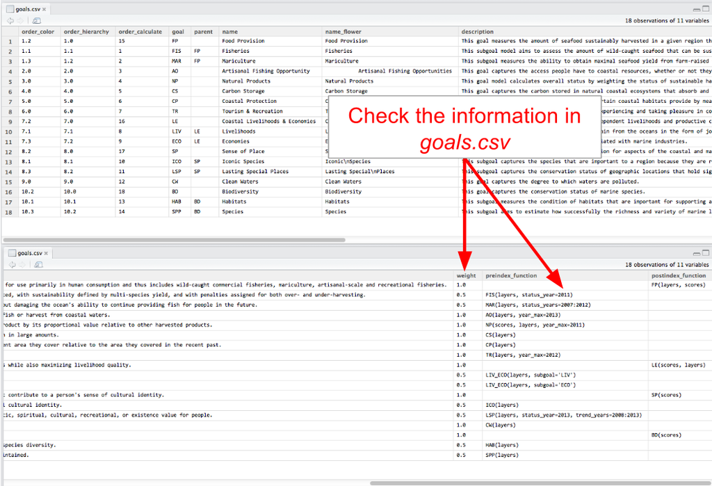

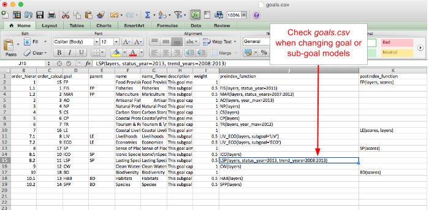